# STA 141A Final Project

Daniel Wallace

3/14/2022

### B. Introduction

In the first few months of the coronavirus disease 2019 (COVID-19) pandemic, many countries around the world implemented “lockdowns” in which individuals were asked not to leave their homes to help “flatten the curve”. In other words, the goal was to spread out the rate of infection by the severe acute respiratory syndrome coronavirus 2 (SARS-CoV-2) virus so that the health care systems of respective areas were not overwhelmed with too many people needing critical care in short spans of time. As a result, health care workers could save as many people as possible from dying. If successful, the lockdowns should have resulted in less infections and deaths in the period during and for a short time after the lockdowns than there would have been otherwise. In this report, I analyze country-level data on virus incidence, virus fatality, and policy response to determine whether country-wide lockdown policies first implemented in March 2020 that lasted continuously for a long period (more than two months) and generally required people to not leave their homes with minor exceptions were significantly associated with helping prevent people from catching and dying from COVID-19. If the association is strong, then governments can be more confident that despite the possible risks of imposing a lockdown on a population, the risks may be worthwhile for the sake of saving lives.

The country-level virus incidence and virus fatality data were acquired from the World Health Organization (WHO) [1] while the country-level policy response data was acquired from the Oxford Coronavirus Government Response Tracker (OCGRT) through the Our World in Data project of the Global Change Data Lab organization [2]. For the WHO dataset, a subset of the WHO’s publically available data was used that included data on the daily number of new virus infections, cumulative virus infections, new virus-related deaths, and cumulative virus-related deaths on a per-country basis from January 2020 through October 2020 that were reported to the WHO by each country. The OCGRT data included the level of stay-at-home restrictions a country had from a level of “0” (no stay-at-home policy) to “3” (required to not leave the house with minimal exceptions e.g. allowed to leave only once every few days, or only one person can leave at a time, etc.). A level of “2” (required to not leave the house with exceptions for daily exercise, grocery shopping, and ‘essential’ trips) was chosen for this analysis because that was the level of policy response chosen by the government of the United States in the beginnings of the pandemic. I am most interested in analyzing the United States above all other countries since it is where I was born and raised and have lived throughout the pandemic, and this fact has shaped the nature of the investigation and the countries chosen. As such, data from Belgium, Mexico, Spain, and the United States are used as case studies due to my personal interest in using countries with a policy response similar to the United States, including the length of their lockdowns (greater than two months), when their lockdowns began (March), and the level of stay at home restrictions (level “2”).

### C. Background

The WHO declared a global pandemic of COVID-19 on March 11, 2020. As of March 13, 2022, the pandemic is said to have caused more than six million deaths worldwide and over 993,000 deaths in the United States. In response, several measures have been proposed to reduce the number of infections. Since the virus is predominantly transmitted via small liquid particles emitted from an infected person’s mouth and nose, the most widely implemented measures have people keep their distance from each other and cover their mouths and noses with some sort of barrier. These measures include wearing masks, “social distancing” by staying more than six-feet away from others, and stay-at-home requirements, also known as “lockdowns”.

Although there was and continues to be debate as to whether the benefits of lockdowns outweigh the economic and psychological costs, especially for lockdowns that last for several months, many national governments decided the pandemic was serious enough to merit country-wide lockdowns early in the pandemic. According to the OCGRT data, Spain, Belgium, the United States, and Mexico first implemented lockdowns March 14, March 18, March 15, and March 30, respectively, and lasted 74 days, 82 days, 127 days, and 165 days, respectively. Assessing the impact of these and other lockdowns is complicated by the fact that the frequency of virus testing and the criteria for reporting whether a person has the virus or a death was caused by the virus varies widely between countries and may change over time. For instance, in Belgium, it is possible that the country over-reported the number of cases of the virus, with suspected cases being reported along with confirmed cases.

### D. Descriptive Analysis

[output not shown]

The following table describes the period and duration of the lockdown for each country as well as summary statistics detailing what occurred in regards to new cases and deaths during the intervention period. Each period consisted of the lockdown period and 14 days afterward; this is because because the WHO has found that the virus takes up to 14 days to incubate [3]. As such, the full effect of the lockdown intervention will include up to 14 days after the lockdown ends.

Mexico had by far the longest lockdown, which was more than a month longer than the second longest, the United States, and more than twice as long as the third longest, Belgium. The high numbers that the United States has compared to other countries can likely be explained in part by it having a much largest population than the other countries. As such, it had the largest range of daily cases and daily deaths, with highs of 76,791 cases and 2,699 deaths, the largest medians of daily cases and daily deaths at 27,030 cases and 965 deaths, respectively, and the highest standard deviation of daily cases and daily deaths at 18,076 cases and 663.99 deaths, respectively. It is likely that Belgium having the lowest numbers can be explained similarly since it has the smallest population of all the countries examined. The median was used instead of the mean to represent the average of the distributions because for most of the distributions, the mean differed significantly from the median, indicating skewed distributions and the median better representing the distributions’ centers.

| Lockdown_period | Lockdown_duration | Range_daily_cases | Standard_deviation_daily_cases | Median_daily_cases | Range_daily_deaths | Standard_deviation_daily_deaths | Median_daily_deaths |
| --- | --- | --- | --- | --- | --- | --- | --- |
| March 14 to May 26 | 74 days | 143 to 10,136 cases | 2701.9 cases | 1694.5 | 21 to 913 deaths | 291.46 deaths | 212.50 deaths |
| March 18 to June 7 | 82 days | 22 to 2,336.0 cases | 579.03 cases | 432.0 | 4 to 324 deaths | 93.065 deaths | 70.5 deaths |
| March 15 to July 19 | 127 days | 951 to 76,791 cases | 18,076 cases | 27,030 | 11 to 2699 deaths | 663.99 deaths | 965 deaths |
| March 30 to September 10 | 165 days | 166 to 9,133 cases | 2535.4 cases | 4,132 | 9 to 840 deaths | 224.84 deaths | 575 deaths |

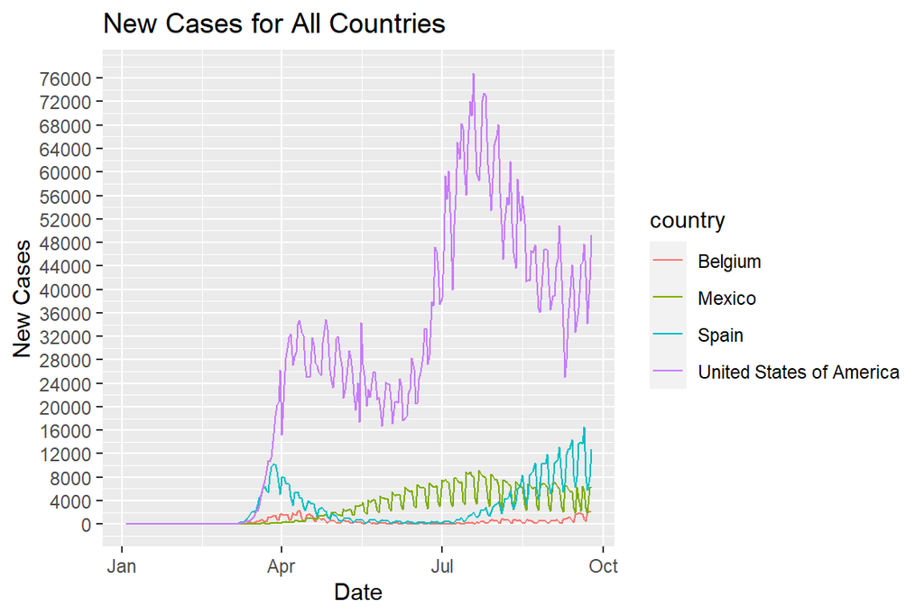

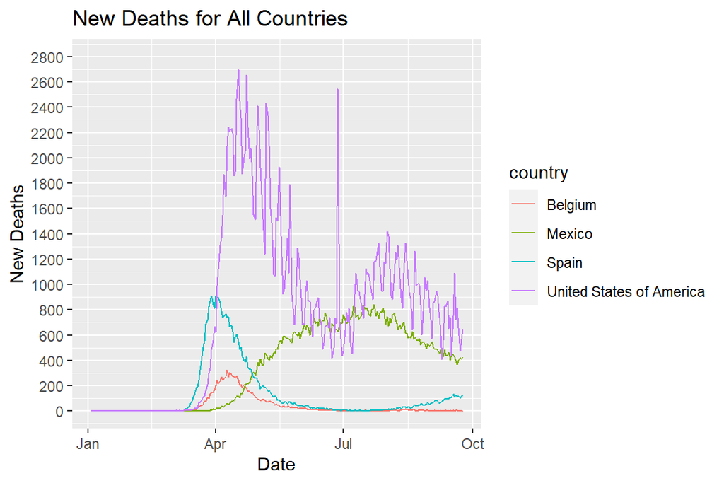

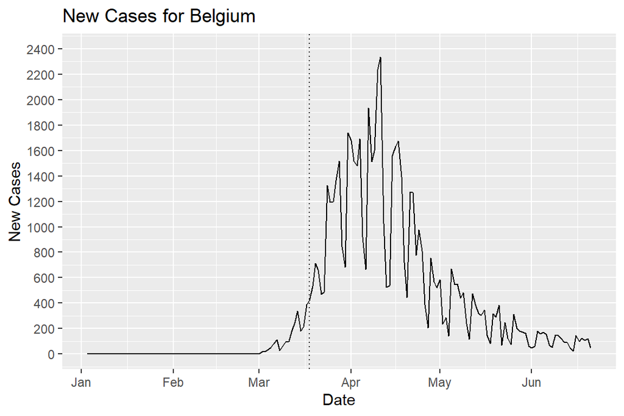

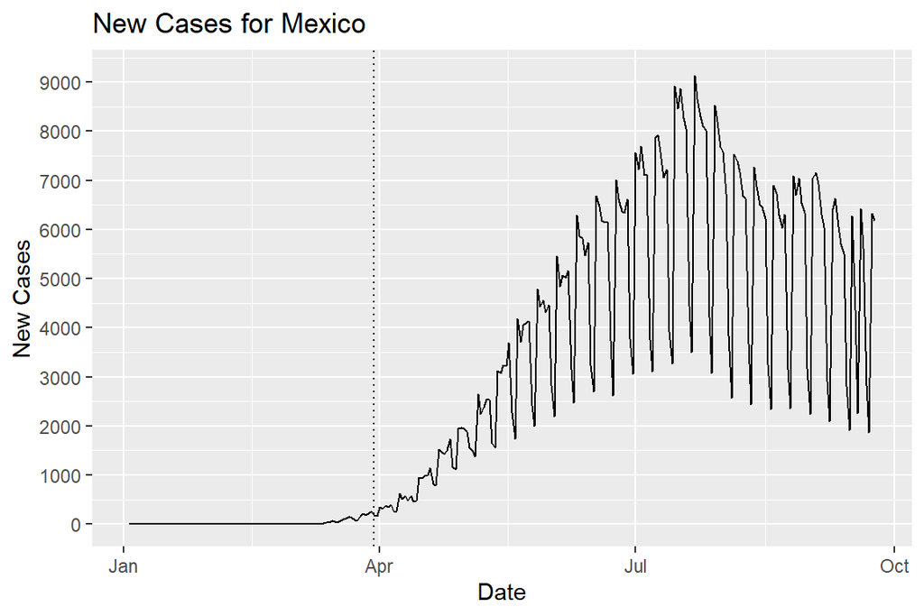

For tests for statistical significance to be conducted, models will have to be fitted to compare the expected counts and the observed counts of new cases and new deaths for each country. The following graphs provide evidence that for each distribution for each country, a log transformation of the variables leads to distributions that appear to be able to be modeled decently with linear relationships to time. It follows that a linear regression and interrupted time series model may be warranted.

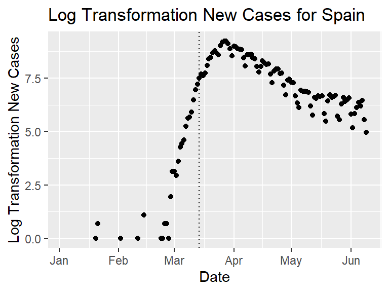

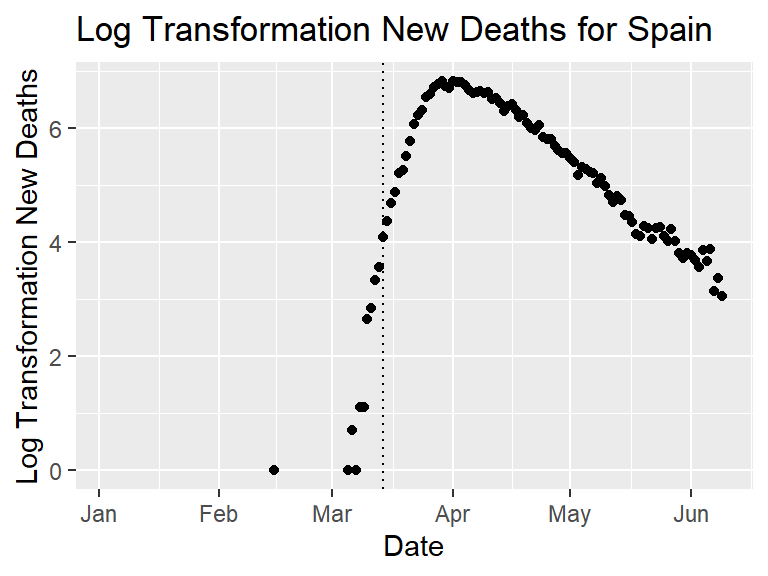

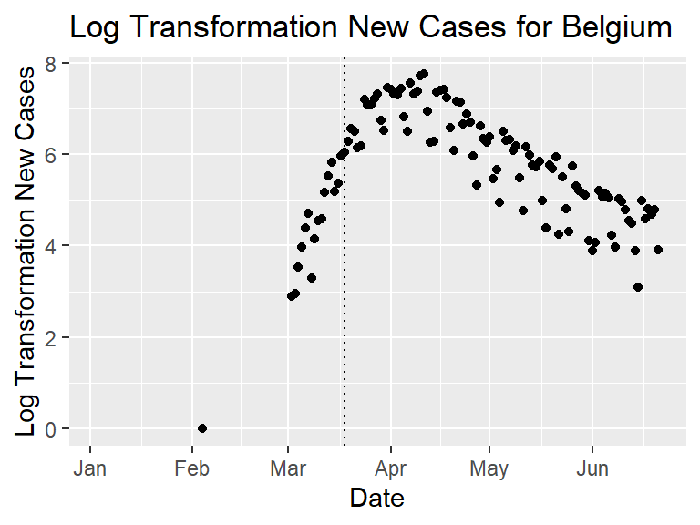

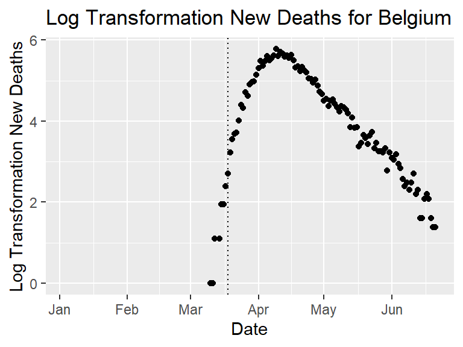

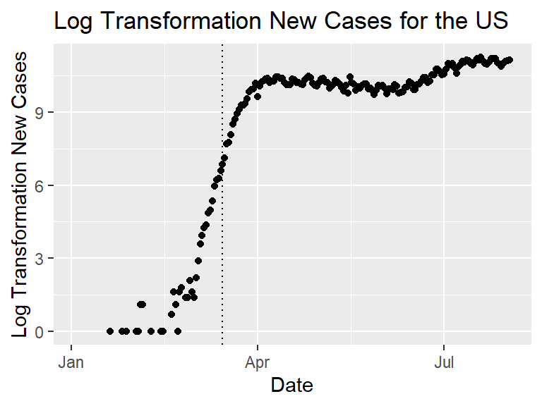

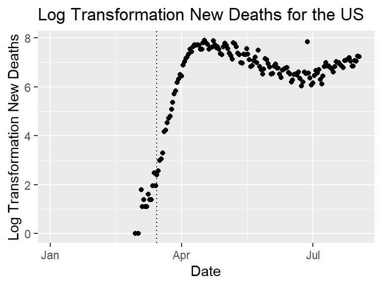

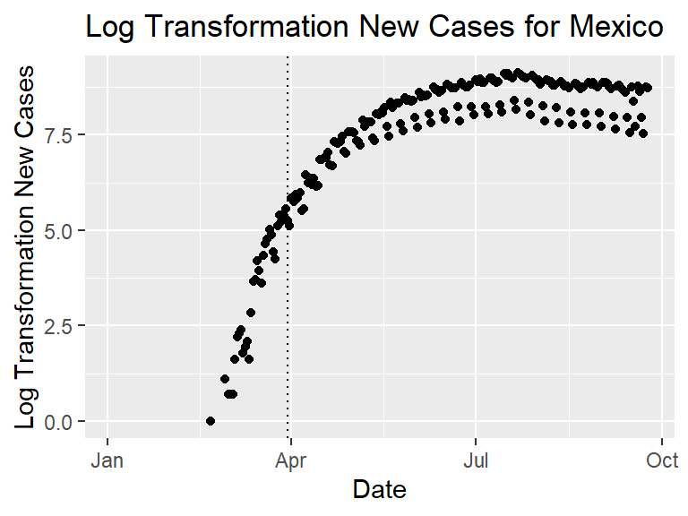

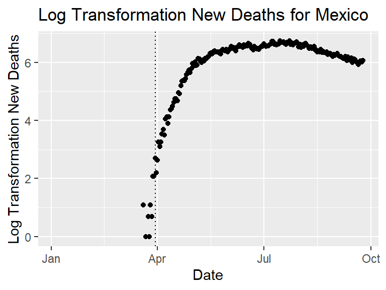

### E. Inferential Analysis

To test whether lockdowns has a significant effect of virus incidence and death, I propose the following ordinary least squares regression model with a logarithmic transformation on the dependent variable
$${Y_t}$$
and an interrupted time series (ITS) design.

$${Y_t}= \alpha + \beta_1 x_1\ + \beta_2 x_2 + \beta_3 x_3 + \epsilon$$

where
$${Y_t}$$
represents the log transform of new cases or new deaths,
$${X_1}$$
represents the pre-intervention trend,
$${X_2}$$
represents the level change immediately after policy intervention,
$${X_3}$$
represents the slope change following the lockdown calculated ax a product of
$${X_1}$$
and
$${X_2}$$
, and
$$\epsilon$$
is the error term. The assumptions of the model are as follows: the error term has a population mean of zero (taken care of by including the constant term
$$\alpha$$
; the independent variables are uncorrelated to the error term; observations of the error term are uncorrelated to each other; and the error term has a constant variance. A statistically significant and positive
$$\beta_1$$
would be a positive trend before the intervention, and a statistically significant and negative
$$\beta_3$$
= would mean a negative trend of cases/deaths after intervention/ The model assumes that the average and the trend of the series would be constant without country-level intervention. Again, the intervention for each lasts from the beginning of their lockdowns and the end is marked by 14 days after the lockdown ends since that is the maximum incubation of the virus according to the WHO.With this model, if my hypothesis is correct of the intervention leading to a statistically significant difference in virus incidences and deaths, than
$$\beta_3$$
will be statistically significant and negative.

[output not shown]

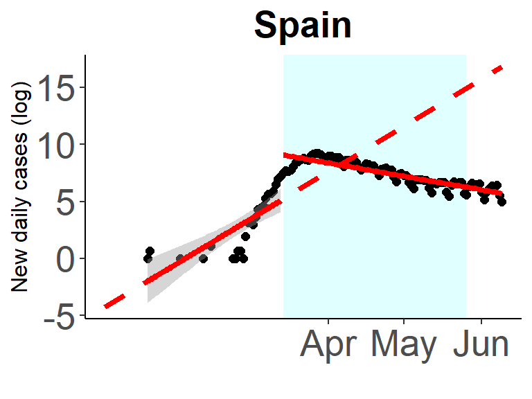

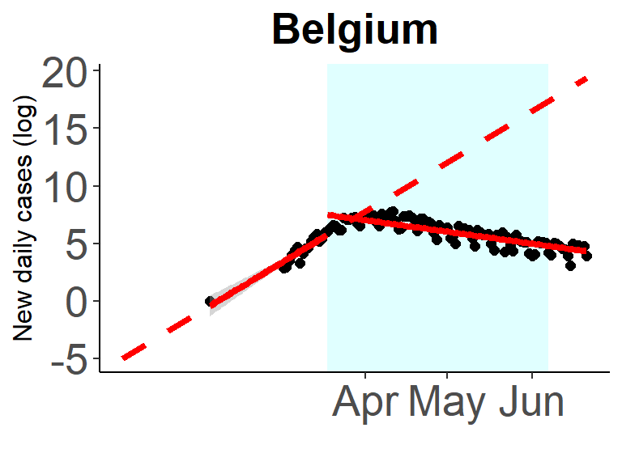

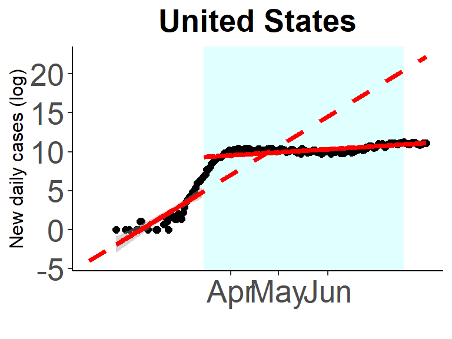

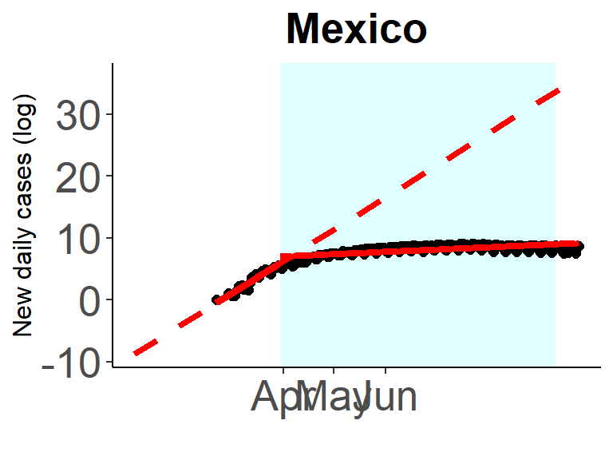

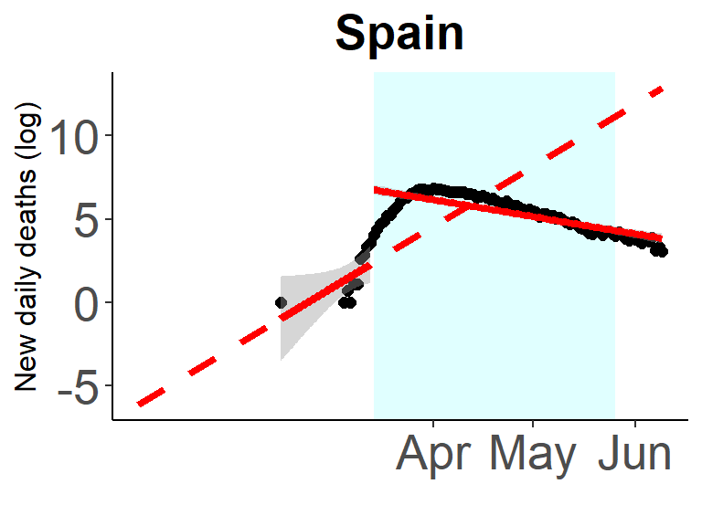

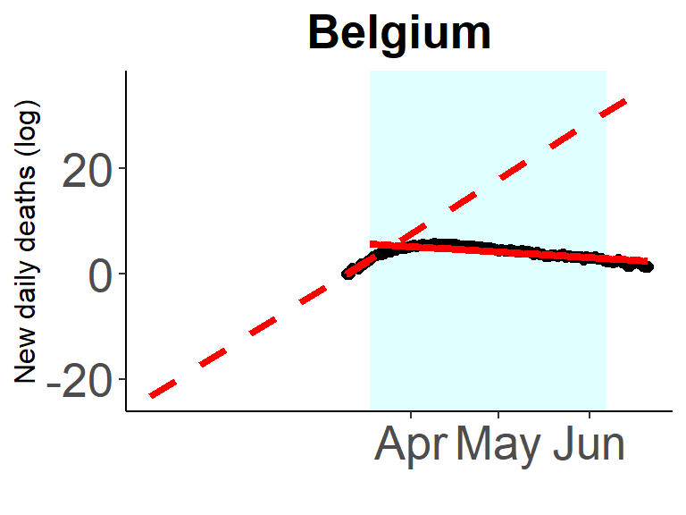

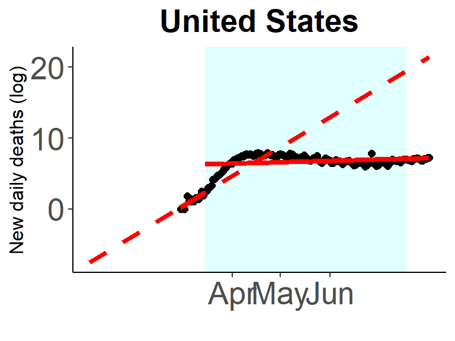

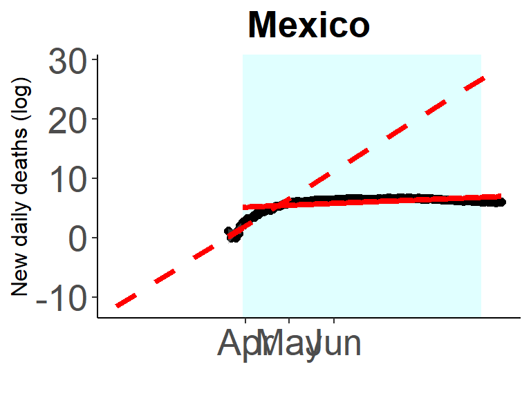

| Spain | Belgium | United_States | Mexico |
| --- | --- | --- | --- |
| -4.3826 (***) (0.7170) | -5.1622 (***) (1.0285) | -4.1257 (***) (0.4364) | -8.8911 (***) (0.8700) |
| 0.13316 (***) (0.01256) | 0.14357 (***) (0.01555) | 0.12357 (***) (0.00807) | 0.16895 (***) (0.01202) |
| 4.0272 (***) (0.3300) | 1.9175 (***) (0.2402) | 4.5225 (***) (0.2321) | 1.1815 (***) (0.2357) |
| -0.17165 (***) (0.01312) | -0.17699 (***) (0.01571) | -0.11075 (***) (0.00820) | -0.15678 (***) (0.01206) |
| 0.8628 | 0.7984 | 0.9577 | 0.9037 |

| Spain | Belgium | United_States | Mexico |
| --- | --- | --- | --- |
| -6.2497 (**) (2.1145) | -23.617 (**) (8.342) | -7.6505 (.) (4.2847) | -11.70050 (>0.1) (7.49161) |
| 0.12017 (***) (0.03247) | 0.3469 (**) (0.1165) | 0.13648 (*) (0.06502) | 0.15240 (.) (0.09007) |
| 4.5101 (***) (0.3529) | 3.2718 (***) (0.5141) | 4.1149 (***) (0.51233) | 3.57045 (***) (0.44662) |
| -0.15360 (***) (0.03263) | -0.3808 (**) (0.1165) | -0.13025 (*) (0.06505) | -0.14230 (>0.1) (0.09008) |
| 0.7896 | 0.7161 | 0.7211 | 0.7196 |

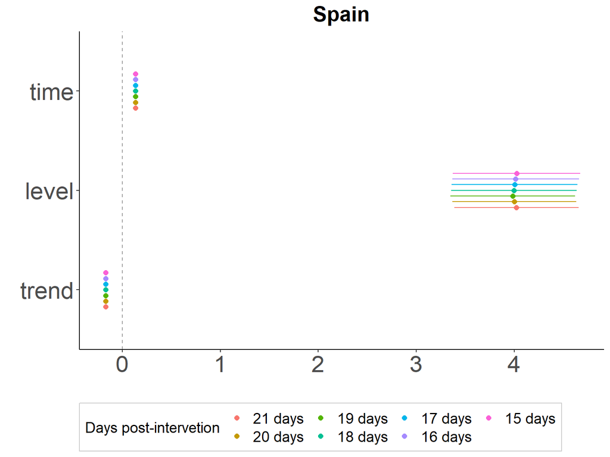

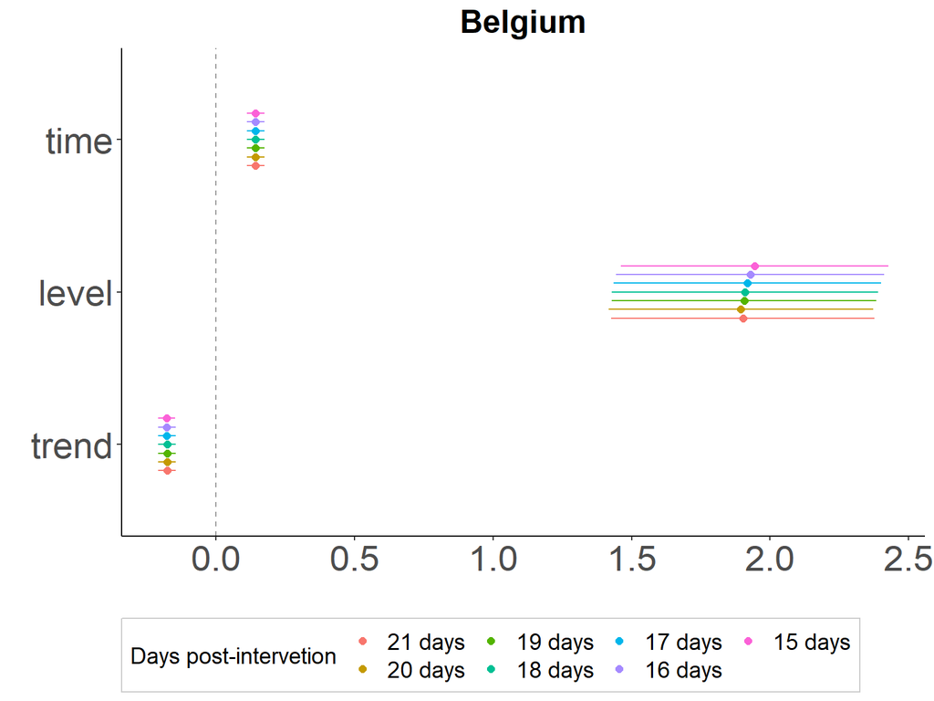

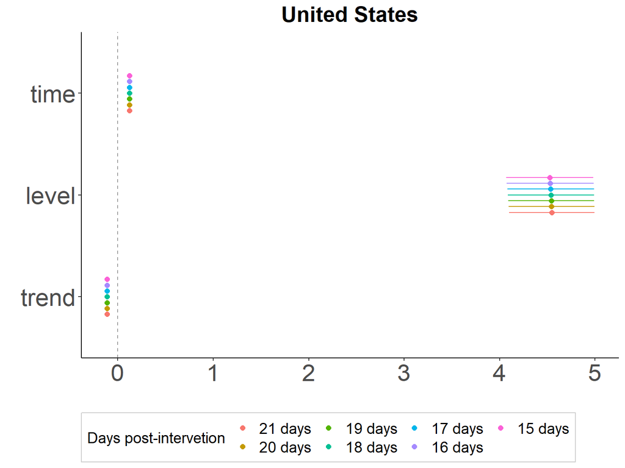

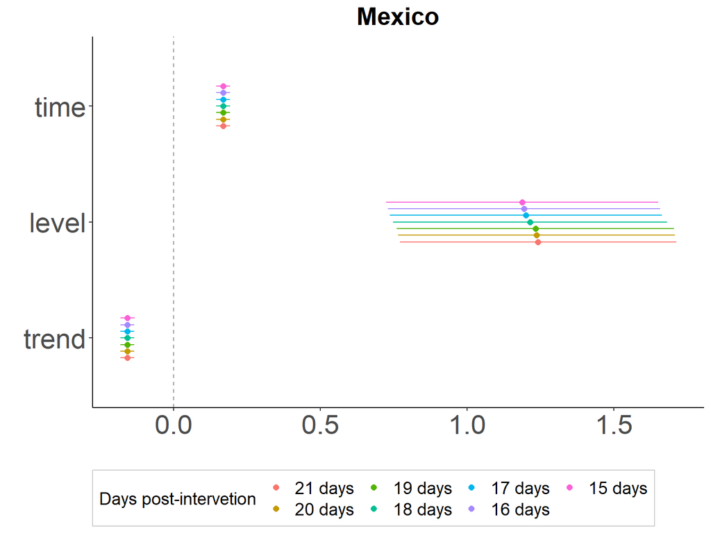

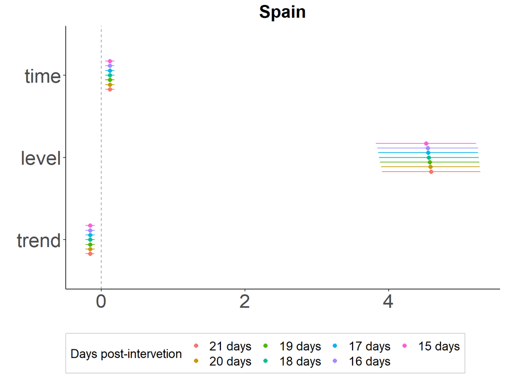

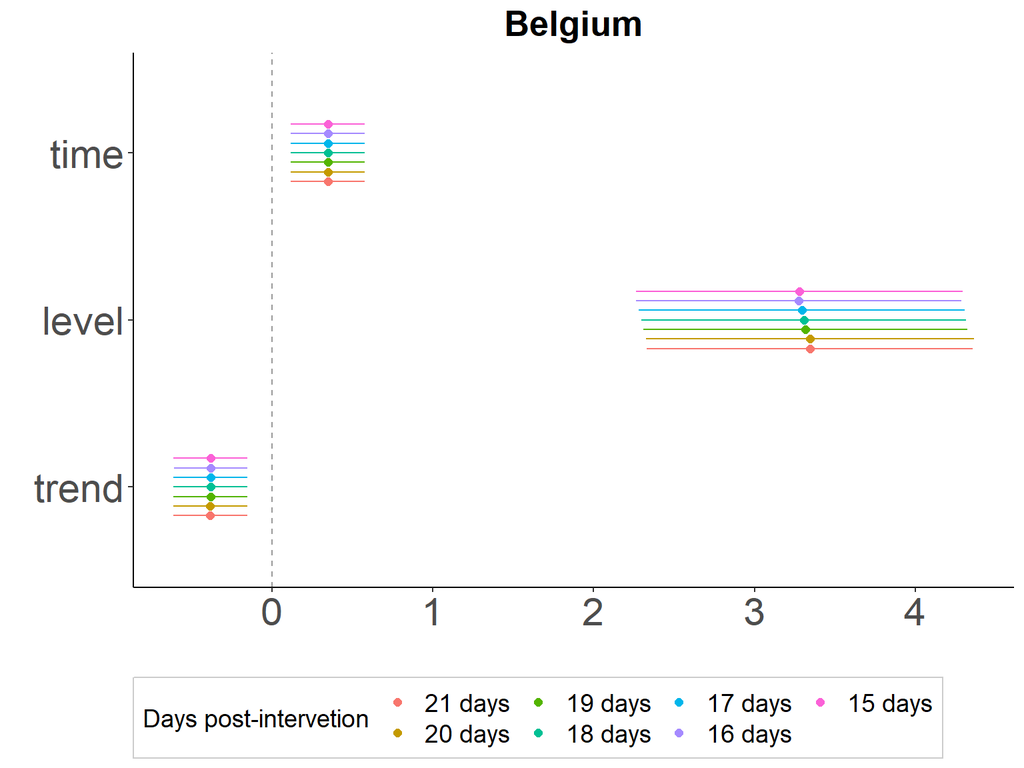

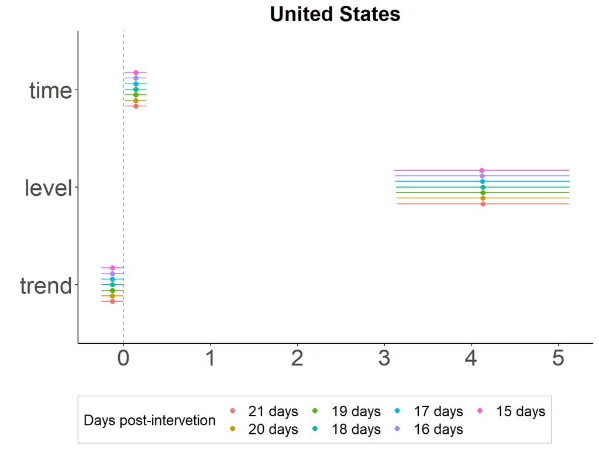

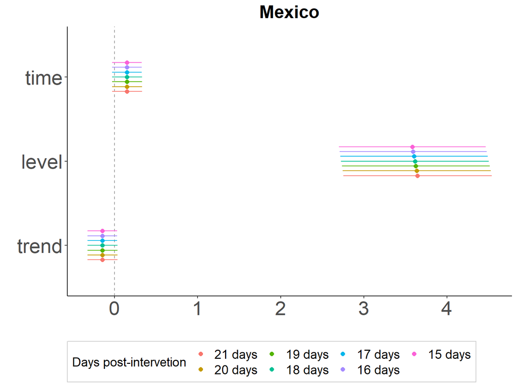